# Lecture 6

12 February 2019

## Structure

1. Pricing introduction
2. Simple regression
3. Mixed effect models

## Pricing types

## Based on product type

- new products (price setting)
  - refer to any marketing introduction book
    - surveys, focus groups
    - market elasticity, competition prices, pricing objectives, …
  - choosing a similar product as benchmark
- existing products (price corrections)
  - different products (manufacturers)
    - similar to new products
    - benchmarking against similar products
  - same products (retailers, wholesalers)
    - main focus today
      - enough data to properly analyse

## Important concepts

- elasticity
- substitutes & complements
  - cross-elasticity

recall you microeconomics class

## Simple regression

## Log-log linear model & elasticities

from elasticity to log-log model

\(E = \frac{\frac{\partial Q}{Q}} {\frac{\partial P}{P}} = \frac{\partial Q}{\partial P}\frac{P}{Q} \Rightarrow \frac{\partial Q}{Q} = E\frac{\partial P}{P}\)  
\(\ln Q = E \ln P + c \Rightarrow \ln Q = \alpha + \beta \ln P\)

similarly for cross-elasticities

\(ln Q = \alpha + \beta_{0} \ln P_{0} + \beta_{1} \ln P_{1} + \cdots + \beta_{n} \ln P_{n}\)  
- \(\beta_{j} > 0 \Rightarrow\) substitutes, \(j > 0\)  
- \(\beta_{j} < 0 \Rightarrow\) complements, \(j > 0\)

## Much ado about elasticities?

- elasticity coefficient
  - revenues development in price change
  - determines price change desirability
  - insufficient on it’s own
- adding price index
  - product relative price
  - determines the price change direction
- together:
  - where I want to move the price
  - is it desirable?

## PIE matrix

- not a technical term
- PriceIndex-Elasticity matrix

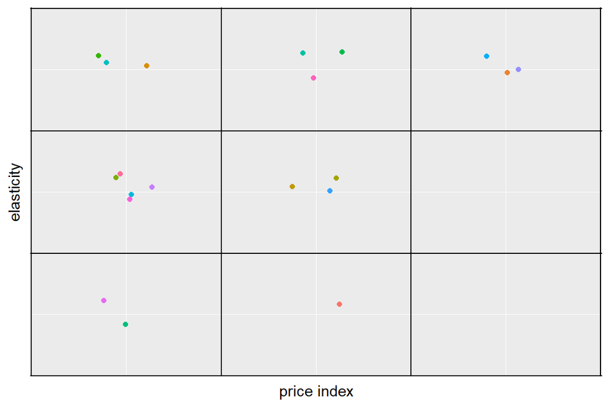

## PIE matrix interpretation

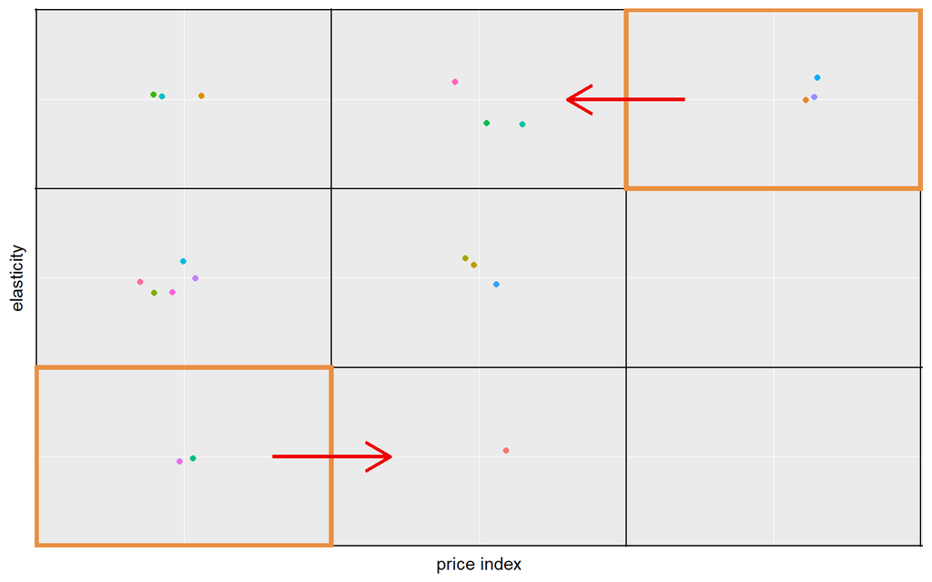

## What is missing?

- the target price is set
- how to achieve it
- how about promotions / discounts
  - everyday low?
  - high-low strategy?
- promo / nopromo elasticity

## PENE matrix

- again, no technical term
- PromoElasticity-NopromoElasticity

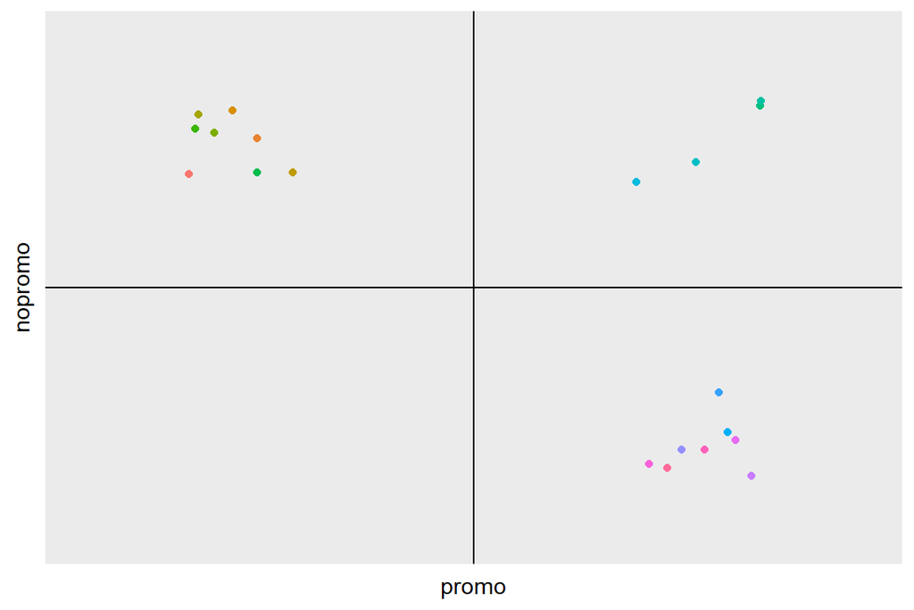

## PENE matrix interpretation

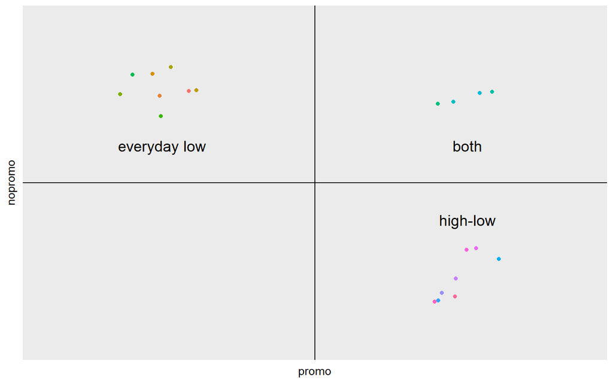

## Cross elasticities

- high-dimensional data
  - for \(k\) products we have \(k^{2}\) coefficients
  - needs to be controlled (LASSO)
- could be used as secondary source
  - optimising a category
  - constructing a cross-category bundles

## Mixed effect models

## Back to model estimation

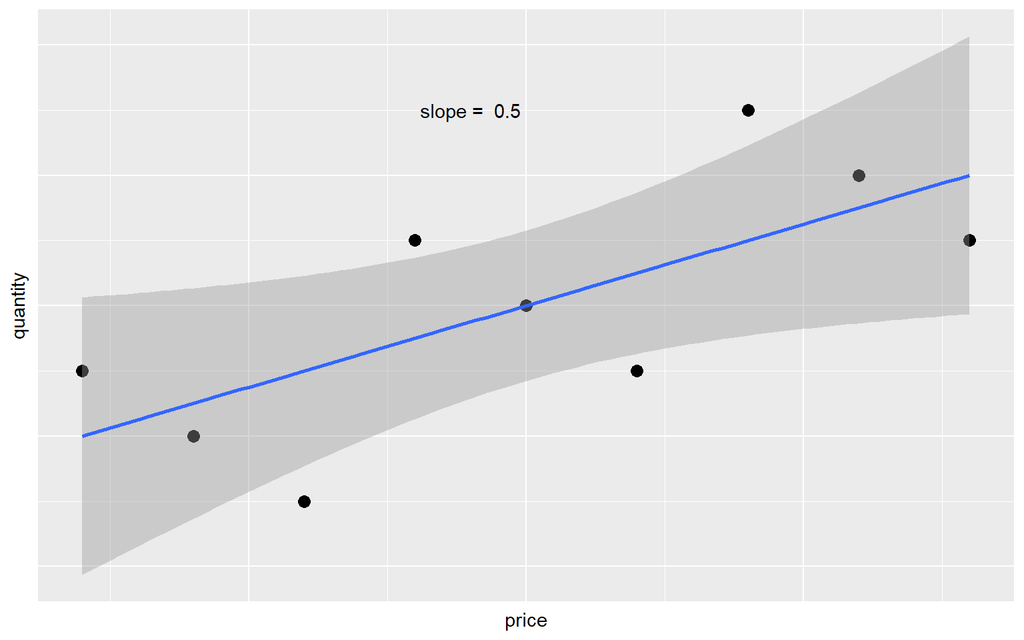

## How about segmentation?

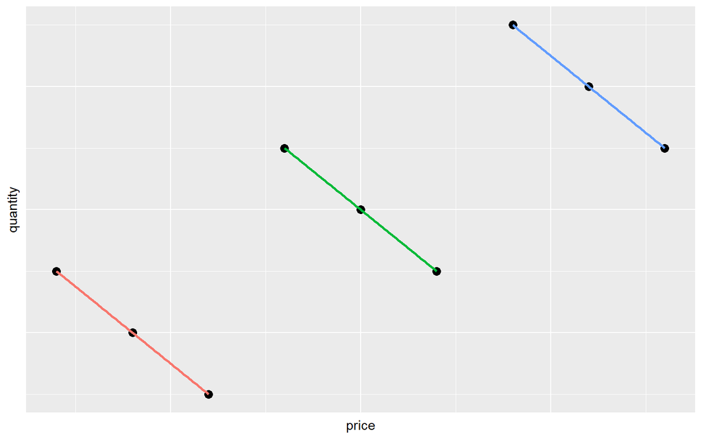

## Possible segments

- location and store
  - urban / rural
  - town size
  - channel
  - distance to competition
- product
  - category
  - manufacturer
- customers
  - price segmentation
  - promo segmentation

## Hierachy in model

- dummy-variables
  - intercept only
- large number of models
  - for each group
- mixed effect models
  - estimating overall (fixed) and group (random) effects

## Mixed effect models

- avoids the curse of averages
  - the average of \(-1\) and \(+1\) is \(0\)
- \(y = X\beta + Z \mu + \epsilon\)
- maximum likelihood estimation
- better than group of simple lm:
  - data pooling - less data demanding
  - shrinking towards overall average
  - single framework
- classical implementation - lme4::lmer

## Solving segmentation by mixed effect model

```
## boundary (singular) fit: see ?isSingular
```

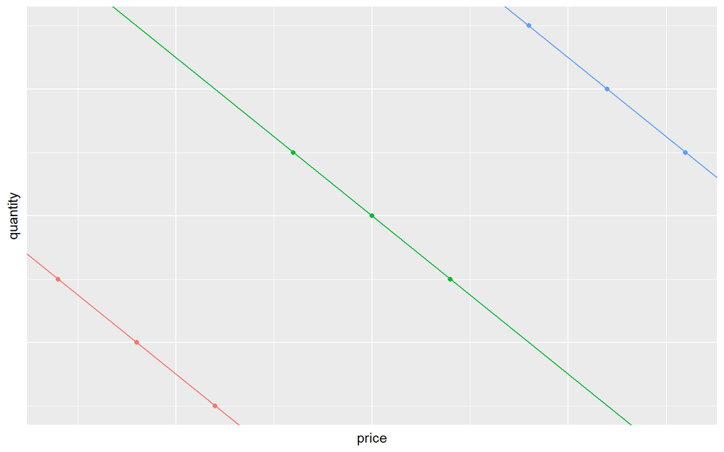

## Mixed versus simple regression

- mixed effects
  - very computionally intensive
  - harder to interpret
  - solving averaging problem
- linear regression
  - simpler
    - computation and interpretation
  - potentionally misleading